# Risk Factor Analysis

## Outcome Variable

**Outcome Variable:** whz

## Predictor Variables

**Intervention Variable:** month

**Adjustment Set:**

unadjusted

## Stratifying Variables

The analysis was stratified on these variable(s):

- agecat
- studyid
- country

## Data Summary

| agecat | studyid | country | month | n_cell | n |
| --- | --- | --- | --- | --- | --- |
| Birth | ki0047075b-MAL-ED | BANGLADESH | 1 | 19 | 241 |
| Birth | ki0047075b-MAL-ED | BANGLADESH | 2 | 21 | 241 |
| Birth | ki0047075b-MAL-ED | BANGLADESH | 3 | 25 | 241 |
| Birth | ki0047075b-MAL-ED | BANGLADESH | 4 | 21 | 241 |
| Birth | ki0047075b-MAL-ED | BANGLADESH | 5 | 20 | 241 |
| Birth | ki0047075b-MAL-ED | BANGLADESH | 6 | 8 | 241 |
| Birth | ki0047075b-MAL-ED | BANGLADESH | 7 | 21 | 241 |
| Birth | ki0047075b-MAL-ED | BANGLADESH | 8 | 22 | 241 |
| Birth | ki0047075b-MAL-ED | BANGLADESH | 9 | 20 | 241 |
| Birth | ki0047075b-MAL-ED | BANGLADESH | 10 | 23 | 241 |
| Birth | ki0047075b-MAL-ED | BANGLADESH | 11 | 15 | 241 |
| Birth | ki0047075b-MAL-ED | BANGLADESH | 12 | 26 | 241 |
| Birth | ki0047075b-MAL-ED | BRAZIL | 1 | 9 | 183 |
| Birth | ki0047075b-MAL-ED | BRAZIL | 2 | 19 | 183 |
| Birth | ki0047075b-MAL-ED | BRAZIL | 3 | 17 | 183 |
| Birth | ki0047075b-MAL-ED | BRAZIL | 4 | 8 | 183 |
| Birth | ki0047075b-MAL-ED | BRAZIL | 5 | 16 | 183 |
| Birth | ki0047075b-MAL-ED | BRAZIL | 6 | 7 | 183 |
| Birth | ki0047075b-MAL-ED | BRAZIL | 7 | 17 | 183 |
| Birth | ki0047075b-MAL-ED | BRAZIL | 8 | 17 | 183 |
| Birth | ki0047075b-MAL-ED | BRAZIL | 9 | 27 | 183 |
| Birth | ki0047075b-MAL-ED | BRAZIL | 10 | 18 | 183 |
| Birth | ki0047075b-MAL-ED | BRAZIL | 11 | 15 | 183 |
| Birth | ki0047075b-MAL-ED | BRAZIL | 12 | 13 | 183 |
| Birth | ki0047075b-MAL-ED | INDIA | 1 | 16 | 203 |
| Birth | ki0047075b-MAL-ED | INDIA | 2 | 16 | 203 |
| Birth | ki0047075b-MAL-ED | INDIA | 3 | 20 | 203 |
| Birth | ki0047075b-MAL-ED | INDIA | 4 | 14 | 203 |
| Birth | ki0047075b-MAL-ED | INDIA | 5 | 7 | 203 |
| Birth | ki0047075b-MAL-ED | INDIA | 6 | 17 | 203 |

[output cut: 798 more lines]

The following strata were considered:

- agecat: 24 months, studyid: ki0047075b-MAL-ED, country: BANGLADESH
- agecat: 24 months, studyid: ki0047075b-MAL-ED, country: BRAZIL
- agecat: 24 months, studyid: ki0047075b-MAL-ED, country: INDIA
- agecat: 24 months, studyid: ki0047075b-MAL-ED, country: NEPAL
- agecat: 24 months, studyid: ki0047075b-MAL-ED, country: PERU
- agecat: 24 months, studyid: ki0047075b-MAL-ED, country: SOUTH AFRICA
- agecat: 24 months, studyid: ki0047075b-MAL-ED, country: TANZANIA, UNITED REPUBLIC OF
- agecat: 24 months, studyid: ki1000108-CMC-V-BCS-2002, country: INDIA
- agecat: 24 months, studyid: ki1000108-IRC, country: INDIA
- agecat: 24 months, studyid: ki1017093-NIH-Birth, country: BANGLADESH
- agecat: 24 months, studyid: ki1066203-TanzaniaChild2, country: TANZANIA, UNITED REPUBLIC OF
- agecat: 24 months, studyid: ki1113344-GMS-Nepal, country: NEPAL
- agecat: 24 months, studyid: ki1114097-CMIN, country: BANGLADESH
- agecat: 24 months, studyid: ki1114097-CMIN, country: GUINEA-BISSAU
- agecat: 24 months, studyid: ki1114097-CMIN, country: PERU
- agecat: 24 months, studyid: ki1114097-CONTENT, country: PERU
- agecat: 24 months, studyid: ki1119695-PROBIT, country: BELARUS
- agecat: 24 months, studyid: ki1126311-ZVITAMBO, country: ZIMBABWE
- agecat: 24 months, studyid: ki1148112-LCNI-5, country: MALAWI
- agecat: 24 months, studyid: kiGH5241-JiVitA-3, country: BANGLADESH
- agecat: 24 months, studyid: kiGH5241-JiVitA-4, country: BANGLADESH
- agecat: 6 months, studyid: ki0047075b-MAL-ED, country: BANGLADESH
- agecat: 6 months, studyid: ki0047075b-MAL-ED, country: BRAZIL
- agecat: 6 months, studyid: ki0047075b-MAL-ED, country: INDIA
- agecat: 6 months, studyid: ki0047075b-MAL-ED, country: NEPAL
- agecat: 6 months, studyid: ki0047075b-MAL-ED, country: PERU
- agecat: 6 months, studyid: ki0047075b-MAL-ED, country: SOUTH AFRICA
- agecat: 6 months, studyid: ki0047075b-MAL-ED, country: TANZANIA, UNITED REPUBLIC OF
- agecat: 6 months, studyid: ki1000108-CMC-V-BCS-2002, country: INDIA
- agecat: 6 months, studyid: ki1000108-IRC, country: INDIA
- agecat: 6 months, studyid: ki1000109-EE, country: PAKISTAN
- agecat: 6 months, studyid: ki1000109-ResPak, country: PAKISTAN
- agecat: 6 months, studyid: ki1000304b-SAS-CompFeed, country: INDIA
- agecat: 6 months, studyid: ki1000304b-SAS-FoodSuppl, country: INDIA
- agecat: 6 months, studyid: ki1017093-NIH-Birth, country: BANGLADESH
- agecat: 6 months, studyid: ki1066203-TanzaniaChild2, country: TANZANIA, UNITED REPUBLIC OF
- agecat: 6 months, studyid: ki1112895-Guatemala BSC, country: GUATEMALA
- agecat: 6 months, studyid: ki1113344-GMS-Nepal, country: NEPAL
- agecat: 6 months, studyid: ki1114097-CMIN, country: BANGLADESH
- agecat: 6 months, studyid: ki1114097-CMIN, country: BRAZIL
- agecat: 6 months, studyid: ki1114097-CMIN, country: GUINEA-BISSAU
- agecat: 6 months, studyid: ki1114097-CMIN, country: PERU
- agecat: 6 months, studyid: ki1114097-CONTENT, country: PERU
- agecat: 6 months, studyid: ki1119695-PROBIT, country: BELARUS
- agecat: 6 months, studyid: ki1126311-ZVITAMBO, country: ZIMBABWE
- agecat: 6 months, studyid: ki1148112-LCNI-5, country: MALAWI
- agecat: 6 months, studyid: kiGH5241-JiVitA-3, country: BANGLADESH
- agecat: 6 months, studyid: kiGH5241-JiVitA-4, country: BANGLADESH
- agecat: Birth, studyid: ki0047075b-MAL-ED, country: BANGLADESH
- agecat: Birth, studyid: ki0047075b-MAL-ED, country: BRAZIL
- agecat: Birth, studyid: ki0047075b-MAL-ED, country: INDIA
- agecat: Birth, studyid: ki0047075b-MAL-ED, country: NEPAL
- agecat: Birth, studyid: ki0047075b-MAL-ED, country: PERU
- agecat: Birth, studyid: ki0047075b-MAL-ED, country: SOUTH AFRICA
- agecat: Birth, studyid: ki0047075b-MAL-ED, country: TANZANIA, UNITED REPUBLIC OF
- agecat: Birth, studyid: ki1000108-CMC-V-BCS-2002, country: INDIA
- agecat: Birth, studyid: ki1000108-IRC, country: INDIA
- agecat: Birth, studyid: ki1000109-EE, country: PAKISTAN
- agecat: Birth, studyid: ki1000109-ResPak, country: PAKISTAN
- agecat: Birth, studyid: ki1000304b-SAS-CompFeed, country: INDIA
- agecat: Birth, studyid: ki1017093-NIH-Birth, country: BANGLADESH
- agecat: Birth, studyid: ki1114097-CMIN, country: BANGLADESH
- agecat: Birth, studyid: ki1114097-CMIN, country: BRAZIL
- agecat: Birth, studyid: ki1114097-CMIN, country: PERU
- agecat: Birth, studyid: ki1114097-CONTENT, country: PERU
- agecat: Birth, studyid: ki1119695-PROBIT, country: BELARUS
- agecat: Birth, studyid: ki1126311-ZVITAMBO, country: ZIMBABWE
- agecat: Birth, studyid: kiGH5241-JiVitA-3, country: BANGLADESH
- agecat: Birth, studyid: kiGH5241-JiVitA-4, country: BANGLADESH

### Dropped Strata

Some strata were dropped due to rare outcomes:

- agecat: Birth, studyid: ki0047075b-MAL-ED, country: TANZANIA, UNITED REPUBLIC OF
- agecat: Birth, studyid: ki1000108-CMC-V-BCS-2002, country: INDIA
- agecat: Birth, studyid: ki1000109-EE, country: PAKISTAN
- agecat: Birth, studyid: ki1000109-ResPak, country: PAKISTAN
- agecat: Birth, studyid: ki1017093-NIH-Birth, country: BANGLADESH
- agecat: Birth, studyid: ki1114097-CMIN, country: BANGLADESH
- agecat: Birth, studyid: ki1114097-CMIN, country: BRAZIL
- agecat: Birth, studyid: ki1114097-CMIN, country: PERU
- agecat: Birth, studyid: ki1114097-CONTENT, country: PERU
- agecat: Birth, studyid: kiGH5241-JiVitA-4, country: BANGLADESH
- agecat: 6 months, studyid: ki1000109-EE, country: PAKISTAN
- agecat: 6 months, studyid: ki1000109-ResPak, country: PAKISTAN
- agecat: 6 months, studyid: ki1000304b-SAS-FoodSuppl, country: INDIA
- agecat: 6 months, studyid: ki1113344-GMS-Nepal, country: NEPAL
- agecat: 6 months, studyid: ki1114097-CMIN, country: BANGLADESH
- agecat: 6 months, studyid: ki1114097-CMIN, country: BRAZIL
- agecat: 24 months, studyid: ki1066203-TanzaniaChild2, country: TANZANIA, UNITED REPUBLIC OF
- agecat: 24 months, studyid: ki1113344-GMS-Nepal, country: NEPAL
- agecat: 24 months, studyid: ki1114097-CMIN, country: BANGLADESH
- agecat: 24 months, studyid: ki1114097-CONTENT, country: PERU
- agecat: 24 months, studyid: ki1126311-ZVITAMBO, country: ZIMBABWE

## Methods Detail

We’re interested in the causal parameters $E[Y_a]$ for all values of $a \in \mathcal{A}$. These parameters represent the mean outcome if, possibly contrary to fact, we intervened to set all units to have $A=a$. Under the randomization and positivity assumptions, these are identified by the statistical parameters $\psi_a=E_W[E_{Y|A,W}(Y|A=a,W)]$. In addition, we’re interested in the mean of $Y$, $E[Y]$ under no intervention (the observed mean). We will estimate these parameters by using SuperLearner to fit the relevant likelihood factors – $E_{Y|A,W}(Y|A=a,W)$ and $p(A=a|W)$, and then updating our likelihood fit using a joint TMLE.

For unadjusted analyses ($W=\{\}$), initial likelihoods were estimated using Lrnr_glm to estimate the simple $E(Y|A)$ and Lrnr_mean to estimate $p(A)$. For adjusted analyses, a small library containing Lrnr_glmnet, Lrnr_xgboost, and Lrnr_mean was used.

Having estimated these parameters, we will then use the delta method to estimate relative risks and attributable risks relative to a prespecified baseline level of $A$.

# Results Detail

## Results Plots

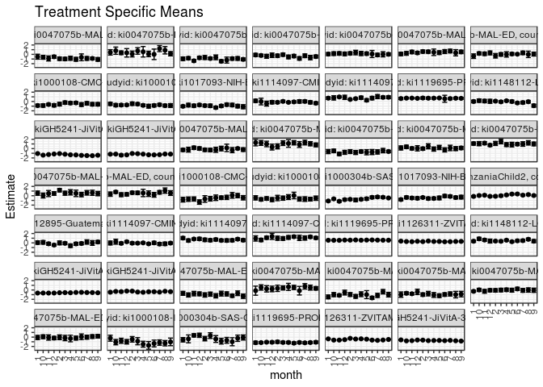

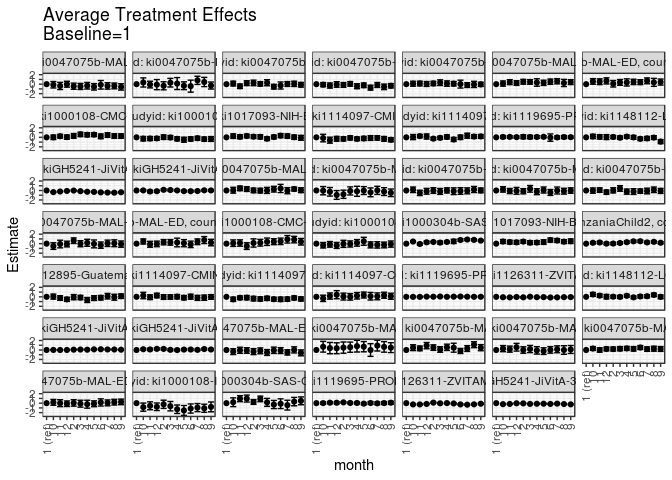

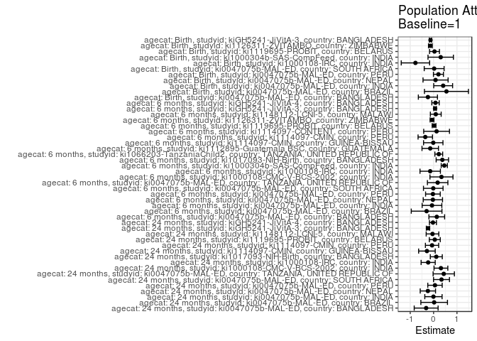

## Results Table

### Parameter: TSM

| agecat | studyid | country | intervention_level | baseline_level | estimate | ci_lower | ci_upper |
| --- | --- | --- | --- | --- | --- | --- | --- |
| Birth | ki0047075b-MAL-ED | BANGLADESH | 1 | NA | -0.7194737 | -1.1398772 | -0.2990701 |
| Birth | ki0047075b-MAL-ED | BANGLADESH | 2 | NA | -1.0657143 | -1.5280624 | -0.6033662 |
| Birth | ki0047075b-MAL-ED | BANGLADESH | 3 | NA | -0.8908000 | -1.3427381 | -0.4388619 |
| Birth | ki0047075b-MAL-ED | BANGLADESH | 4 | NA | -1.2461905 | -1.6981294 | -0.7942516 |
| Birth | ki0047075b-MAL-ED | BANGLADESH | 5 | NA | -0.7740000 | -1.2879349 | -0.2600651 |
| Birth | ki0047075b-MAL-ED | BANGLADESH | 6 | NA | -0.8387500 | -1.2912190 | -0.3862810 |
| Birth | ki0047075b-MAL-ED | BANGLADESH | 7 | NA | -1.2266667 | -1.5828033 | -0.8705300 |
| Birth | ki0047075b-MAL-ED | BANGLADESH | 8 | NA | -0.7013636 | -1.1961891 | -0.2065382 |
| Birth | ki0047075b-MAL-ED | BANGLADESH | 9 | NA | -1.3270000 | -1.7934925 | -0.8605075 |
| Birth | ki0047075b-MAL-ED | BANGLADESH | 10 | NA | -1.0686957 | -1.5079824 | -0.6294089 |
| Birth | ki0047075b-MAL-ED | BANGLADESH | 11 | NA | -0.7733333 | -1.2571551 | -0.2895115 |
| Birth | ki0047075b-MAL-ED | BANGLADESH | 12 | NA | -0.8273077 | -1.2468235 | -0.4077919 |
| Birth | ki0047075b-MAL-ED | BRAZIL | 1 | NA | -0.1466667 | -1.1210674 | 0.8277341 |
| Birth | ki0047075b-MAL-ED | BRAZIL | 2 | NA | 0.3573684 | -0.3146809 | 1.0294177 |
| Birth | ki0047075b-MAL-ED | BRAZIL | 3 | NA | 0.4447059 | -0.0012969 | 0.8907086 |
| Birth | ki0047075b-MAL-ED | BRAZIL | 4 | NA | 0.6637500 | -0.0937747 | 1.4212747 |
| Birth | ki0047075b-MAL-ED | BRAZIL | 5 | NA | 0.5506250 | 0.0888042 | 1.0124458 |
| Birth | ki0047075b-MAL-ED | BRAZIL | 6 | NA | -0.1514286 | -1.0697634 | 0.7669063 |
| Birth | ki0047075b-MAL-ED | BRAZIL | 7 | NA | 0.7770588 | 0.1923716 | 1.3617461 |
| Birth | ki0047075b-MAL-ED | BRAZIL | 8 | NA | 0.5117647 | -0.0240676 | 1.0475970 |
| Birth | ki0047075b-MAL-ED | BRAZIL | 9 | NA | 0.3529630 | -0.0090489 | 0.7149748 |
| Birth | ki0047075b-MAL-ED | BRAZIL | 10 | NA | 0.5372222 | -0.0387250 | 1.1131695 |
| Birth | ki0047075b-MAL-ED | BRAZIL | 11 | NA | 0.2526667 | -0.4257085 | 0.9310418 |
| Birth | ki0047075b-MAL-ED | BRAZIL | 12 | NA | 0.2246154 | -0.3787186 | 0.8279494 |
| Birth | ki0047075b-MAL-ED | INDIA | 1 | NA | -1.4787500 | -1.8919877 | -1.0655123 |
| Birth | ki0047075b-MAL-ED | INDIA | 2 | NA | -0.9737500 | -1.3857743 | -0.5617257 |
| Birth | ki0047075b-MAL-ED | INDIA | 3 | NA | -1.3705000 | -1.7753305 | -0.9656695 |
| Birth | ki0047075b-MAL-ED | INDIA | 4 | NA | -0.9100000 | -1.4323306 | -0.3876694 |
| Birth | ki0047075b-MAL-ED | INDIA | 5 | NA | -0.9942857 | -1.8433430 | -0.1452284 |
| Birth | ki0047075b-MAL-ED | INDIA | 6 | NA | -1.6841176 | -2.0175130 | -1.3507223 |

[output cut: 546 more lines]

### Parameter: E(Y)

| agecat | studyid | country | intervention_level | baseline_level | estimate | ci_lower | ci_upper |
| --- | --- | --- | --- | --- | --- | --- | --- |
| Birth | ki0047075b-MAL-ED | BANGLADESH | NA | NA | -0.9630705 | -1.0989132 | -0.8272278 |
| Birth | ki0047075b-MAL-ED | BRAZIL | NA | NA | 0.4038798 | 0.2296279 | 0.5781316 |
| Birth | ki0047075b-MAL-ED | INDIA | NA | NA | -1.0691133 | -1.2078629 | -0.9303637 |
| Birth | ki0047075b-MAL-ED | NEPAL | NA | NA | -0.9044643 | -1.0439568 | -0.7649718 |
| Birth | ki0047075b-MAL-ED | PERU | NA | NA | -0.0735842 | -0.1836203 | 0.0364518 |
| Birth | ki0047075b-MAL-ED | SOUTH AFRICA | NA | NA | -0.0562791 | -0.2000837 | 0.0875255 |
| Birth | ki1000108-IRC | INDIA | NA | NA | -1.0105831 | -1.1973019 | -0.8238643 |
| Birth | ki1000304b-SAS-CompFeed | INDIA | NA | NA | -0.2697590 | -0.5399211 | 0.0004030 |
| Birth | ki1119695-PROBIT | BELARUS | NA | NA | -1.1463469 | -1.3562674 | -0.9364264 |
| Birth | ki1126311-ZVITAMBO | ZIMBABWE | NA | NA | -0.5149267 | -0.5408101 | -0.4890433 |
| Birth | kiGH5241-JiVitA-3 | BANGLADESH | NA | NA | -0.7240996 | -0.7439385 | -0.7042607 |
| 6 months | ki0047075b-MAL-ED | BANGLADESH | NA | NA | -0.1397960 | -0.2688682 | -0.0107238 |
| 6 months | ki0047075b-MAL-ED | BRAZIL | NA | NA | 0.9717225 | 0.8073791 | 1.1360658 |
| 6 months | ki0047075b-MAL-ED | INDIA | NA | NA | -0.7033969 | -0.8285284 | -0.5782654 |
| 6 months | ki0047075b-MAL-ED | NEPAL | NA | NA | 0.1110452 | -0.0202712 | 0.2423616 |
| 6 months | ki0047075b-MAL-ED | PERU | NA | NA | 1.0543956 | 0.9326967 | 1.1760945 |
| 6 months | ki0047075b-MAL-ED | SOUTH AFRICA | NA | NA | 0.5420735 | 0.3899459 | 0.6942011 |
| 6 months | ki0047075b-MAL-ED | TANZANIA, UNITED REPUBLIC OF | NA | NA | 0.5170513 | 0.3872178 | 0.6468847 |
| 6 months | ki1000108-CMC-V-BCS-2002 | INDIA | NA | NA | -0.5026766 | -0.6536848 | -0.3516685 |
| 6 months | ki1000108-IRC | INDIA | NA | NA | -0.5989297 | -0.7344491 | -0.4634104 |
| 6 months | ki1000304b-SAS-CompFeed | INDIA | NA | NA | -0.6657084 | -0.8024377 | -0.5289791 |
| 6 months | ki1017093-NIH-Birth | BANGLADESH | NA | NA | -0.4389101 | -0.5279432 | -0.3498771 |
| 6 months | ki1066203-TanzaniaChild2 | TANZANIA, UNITED REPUBLIC OF | NA | NA | 0.0809332 | 0.0282644 | 0.1336020 |
| 6 months | ki1112895-Guatemala BSC | GUATEMALA | NA | NA | -0.0840134 | -0.1945572 | 0.0265305 |
| 6 months | ki1114097-CMIN | GUINEA-BISSAU | NA | NA | -0.0418080 | -0.1199942 | 0.0363782 |
| 6 months | ki1114097-CMIN | PERU | NA | NA | 0.6721017 | 0.5829735 | 0.7612299 |
| 6 months | ki1114097-CONTENT | PERU | NA | NA | 1.0684318 | 0.9515274 | 1.1853362 |
| 6 months | ki1119695-PROBIT | BELARUS | NA | NA | 0.5789633 | 0.5190130 | 0.6389137 |
| 6 months | ki1126311-ZVITAMBO | ZIMBABWE | NA | NA | 0.3048776 | 0.2787716 | 0.3309835 |
| 6 months | ki1148112-LCNI-5 | MALAWI | NA | NA | 0.4499285 | 0.3788279 | 0.5210291 |
| 6 months | kiGH5241-JiVitA-3 | BANGLADESH | NA | NA | -0.5935161 | -0.6130518 | -0.5739805 |
| 6 months | kiGH5241-JiVitA-4 | BANGLADESH | NA | NA | -0.3898055 | -0.4270507 | -0.3525603 |
| 24 months | ki0047075b-MAL-ED | BANGLADESH | NA | NA | -0.8208255 | -0.9429246 | -0.6987264 |
| 24 months | ki0047075b-MAL-ED | BRAZIL | NA | NA | 0.4466272 | 0.2416144 | 0.6516401 |
| 24 months | ki0047075b-MAL-ED | INDIA | NA | NA | -0.9522907 | -1.0676596 | -0.8369219 |
| 24 months | ki0047075b-MAL-ED | NEPAL | NA | NA | -0.3764474 | -0.4898516 | -0.2630431 |
| 24 months | ki0047075b-MAL-ED | PERU | NA | NA | 0.1199005 | -0.0000331 | 0.2398341 |
| 24 months | ki0047075b-MAL-ED | SOUTH AFRICA | NA | NA | 0.4267017 | 0.3074751 | 0.5459283 |
| 24 months | ki0047075b-MAL-ED | TANZANIA, UNITED REPUBLIC OF | NA | NA | 0.0500935 | -0.0748234 | 0.1750103 |
| 24 months | ki1000108-CMC-V-BCS-2002 | INDIA | NA | NA | -0.5571505 | -0.6585247 | -0.4557763 |
| 24 months | ki1000108-IRC | INDIA | NA | NA | -0.7458150 | -0.8368180 | -0.6548120 |
| 24 months | ki1017093-NIH-Birth | BANGLADESH | NA | NA | -0.9115790 | -1.0095022 | -0.8136559 |
| 24 months | ki1114097-CMIN | GUINEA-BISSAU | NA | NA | -0.1442438 | -0.2323415 | -0.0561461 |
| 24 months | ki1114097-CMIN | PERU | NA | NA | 0.6477778 | 0.5676685 | 0.7278870 |
| 24 months | ki1119695-PROBIT | BELARUS | NA | NA | 0.6863435 | 0.5745700 | 0.7981170 |
| 24 months | ki1148112-LCNI-5 | MALAWI | NA | NA | -0.0478508 | -0.1297321 | 0.0340305 |
| 24 months | kiGH5241-JiVitA-3 | BANGLADESH | NA | NA | -1.2978031 | -1.3210763 | -1.2745298 |
| 24 months | kiGH5241-JiVitA-4 | BANGLADESH | NA | NA | -1.2231088 | -1.2549632 | -1.1912543 |

### Parameter: ATE

| agecat | studyid | country | intervention_level | baseline_level | estimate | ci_lower | ci_upper |
| --- | --- | --- | --- | --- | --- | --- | --- |
| Birth | ki0047075b-MAL-ED | BANGLADESH | 1 | 1 | 0.0000000 | 0.0000000 | 0.0000000 |
| Birth | ki0047075b-MAL-ED | BANGLADESH | 2 | 1 | -0.3462406 | -0.9711445 | 0.2786633 |
| Birth | ki0047075b-MAL-ED | BANGLADESH | 3 | 1 | -0.1713263 | -0.7885679 | 0.4459153 |
| Birth | ki0047075b-MAL-ED | BANGLADESH | 4 | 1 | -0.5267168 | -1.1439590 | 0.0905254 |
| Birth | ki0047075b-MAL-ED | BANGLADESH | 5 | 1 | -0.0545263 | -0.7185054 | 0.6094528 |
| Birth | ki0047075b-MAL-ED | BANGLADESH | 6 | 1 | -0.1192763 | -0.7369067 | 0.4983541 |
| Birth | ki0047075b-MAL-ED | BANGLADESH | 7 | 1 | -0.5071930 | -1.0581671 | 0.0437811 |
| Birth | ki0047075b-MAL-ED | BANGLADESH | 8 | 1 | 0.0181100 | -0.6311907 | 0.6674108 |
| Birth | ki0047075b-MAL-ED | BANGLADESH | 9 | 1 | -0.6075263 | -1.2355027 | 0.0204501 |
| Birth | ki0047075b-MAL-ED | BANGLADESH | 10 | 1 | -0.3492220 | -0.9572615 | 0.2588175 |
| Birth | ki0047075b-MAL-ED | BANGLADESH | 11 | 1 | -0.0538596 | -0.6948142 | 0.5870949 |
| Birth | ki0047075b-MAL-ED | BANGLADESH | 12 | 1 | -0.1078340 | -0.7017470 | 0.4860790 |
| Birth | ki0047075b-MAL-ED | BRAZIL | 1 | 1 | 0.0000000 | 0.0000000 | 0.0000000 |
| Birth | ki0047075b-MAL-ED | BRAZIL | 2 | 1 | 0.5040351 | -0.6796486 | 1.6877188 |
| Birth | ki0047075b-MAL-ED | BRAZIL | 3 | 1 | 0.5913725 | -0.4802502 | 1.6629953 |
| Birth | ki0047075b-MAL-ED | BRAZIL | 4 | 1 | 0.8104167 | -0.4238040 | 2.0446373 |
| Birth | ki0047075b-MAL-ED | BRAZIL | 5 | 1 | 0.6972917 | -0.3810103 | 1.7755937 |
| Birth | ki0047075b-MAL-ED | BRAZIL | 6 | 1 | -0.0047619 | -1.3437151 | 1.3341913 |
| Birth | ki0047075b-MAL-ED | BRAZIL | 7 | 1 | 0.9237255 | -0.2126354 | 2.0600863 |
| Birth | ki0047075b-MAL-ED | BRAZIL | 8 | 1 | 0.6584314 | -0.4535817 | 1.7704444 |
| Birth | ki0047075b-MAL-ED | BRAZIL | 9 | 1 | 0.4996296 | -0.5398459 | 1.5391052 |
| Birth | ki0047075b-MAL-ED | BRAZIL | 10 | 1 | 0.6838889 | -0.4479998 | 1.8157776 |
| Birth | ki0047075b-MAL-ED | BRAZIL | 11 | 1 | 0.3993333 | -0.7879533 | 1.5866200 |
| Birth | ki0047075b-MAL-ED | BRAZIL | 12 | 1 | 0.3712821 | -0.7747846 | 1.5173487 |
| Birth | ki0047075b-MAL-ED | INDIA | 1 | 1 | 0.0000000 | 0.0000000 | 0.0000000 |
| Birth | ki0047075b-MAL-ED | INDIA | 2 | 1 | 0.5050000 | -0.0785490 | 1.0885490 |
| Birth | ki0047075b-MAL-ED | INDIA | 3 | 1 | 0.1082500 | -0.4702421 | 0.6867421 |
| Birth | ki0047075b-MAL-ED | INDIA | 4 | 1 | 0.5687500 | -0.0972790 | 1.2347790 |
| Birth | ki0047075b-MAL-ED | INDIA | 5 | 1 | 0.4844643 | -0.4598152 | 1.4287437 |
| Birth | ki0047075b-MAL-ED | INDIA | 6 | 1 | -0.2053676 | -0.7363270 | 0.3255917 |

[output cut: 546 more lines]

### Parameter: PAR

| agecat | studyid | country | intervention_level | baseline_level | estimate | ci_lower | ci_upper |
| --- | --- | --- | --- | --- | --- | --- | --- |
| Birth | ki0047075b-MAL-ED | BANGLADESH | 1 | NA | -0.2435969 | -0.6526504 | 0.1654567 |
| Birth | ki0047075b-MAL-ED | BRAZIL | 1 | NA | 0.5505464 | -0.3909584 | 1.4920513 |
| Birth | ki0047075b-MAL-ED | INDIA | 1 | NA | 0.4096367 | 0.0057826 | 0.8134908 |
| Birth | ki0047075b-MAL-ED | NEPAL | 1 | NA | 0.0842857 | -0.4522835 | 0.6208549 |
| Birth | ki0047075b-MAL-ED | PERU | 1 | NA | 0.2072729 | -0.0066646 | 0.4212104 |
| Birth | ki0047075b-MAL-ED | SOUTH AFRICA | 1 | NA | 0.0240913 | -0.4013286 | 0.4495112 |
| Birth | ki1000108-IRC | INDIA | 1 | NA | -0.7775831 | -1.3847921 | -0.1703741 |
| Birth | ki1000304b-SAS-CompFeed | INDIA | 1 | NA | 0.3045267 | -0.2393332 | 0.8483865 |
| Birth | ki1119695-PROBIT | BELARUS | 1 | NA | 0.0387585 | -0.1733834 | 0.2509003 |
| Birth | ki1126311-ZVITAMBO | ZIMBABWE | 1 | NA | -0.1383112 | -0.2185077 | -0.0581147 |
| Birth | kiGH5241-JiVitA-3 | BANGLADESH | 1 | NA | -0.1319547 | -0.1856209 | -0.0782885 |
| 6 months | ki0047075b-MAL-ED | BANGLADESH | 1 | NA | 0.1362824 | -0.2002929 | 0.4728578 |
| 6 months | ki0047075b-MAL-ED | BRAZIL | 1 | NA | -0.2990467 | -0.9557027 | 0.3576092 |
| 6 months | ki0047075b-MAL-ED | INDIA | 1 | NA | -0.0692302 | -0.4908399 | 0.3523795 |
| 6 months | ki0047075b-MAL-ED | NEPAL | 1 | NA | -0.0308215 | -0.4436559 | 0.3820130 |
| 6 months | ki0047075b-MAL-ED | PERU | 1 | NA | -0.0290729 | -0.3427158 | 0.2845701 |
| 6 months | ki0047075b-MAL-ED | SOUTH AFRICA | 1 | NA | -0.0140694 | -0.4328690 | 0.4047302 |
| 6 months | ki0047075b-MAL-ED | TANZANIA, UNITED REPUBLIC OF | 1 | NA | 0.1734281 | -0.2644585 | 0.6113147 |
| 6 months | ki1000108-CMC-V-BCS-2002 | INDIA | 1 | NA | 0.3371999 | -0.1554989 | 0.8298987 |
| 6 months | ki1000108-IRC | INDIA | 1 | NA | -0.1455964 | -0.5821111 | 0.2909183 |
| 6 months | ki1000304b-SAS-CompFeed | INDIA | 1 | NA | 0.4579387 | 0.3262917 | 0.5895856 |
| 6 months | ki1017093-NIH-Birth | BANGLADESH | 1 | NA | 0.3747565 | 0.1098271 | 0.6396860 |
| 6 months | ki1066203-TanzaniaChild2 | TANZANIA, UNITED REPUBLIC OF | 1 | NA | 0.2218293 | 0.0550458 | 0.3886129 |
| 6 months | ki1112895-Guatemala BSC | GUATEMALA | 1 | NA | -0.1442912 | -0.4968524 | 0.2082701 |
| 6 months | ki1114097-CMIN | GUINEA-BISSAU | 1 | NA | -0.0143080 | -0.4292828 | 0.4006668 |
| 6 months | ki1114097-CMIN | PERU | 1 | NA | -0.3559471 | -0.6643634 | -0.0475308 |
| 6 months | ki1114097-CONTENT | PERU | 1 | NA | 0.1282651 | -0.4232608 | 0.6797910 |
| 6 months | ki1119695-PROBIT | BELARUS | 1 | NA | 0.0205392 | -0.0592000 | 0.1002783 |
| 6 months | ki1126311-ZVITAMBO | ZIMBABWE | 1 | NA | -0.0673212 | -0.1490151 | 0.0143727 |
| 6 months | ki1148112-LCNI-5 | MALAWI | 1 | NA | 0.0932012 | -0.1379331 | 0.3243355 |
| 6 months | kiGH5241-JiVitA-3 | BANGLADESH | 1 | NA | 0.0625794 | 0.0065469 | 0.1186120 |
| 6 months | kiGH5241-JiVitA-4 | BANGLADESH | 1 | NA | 0.0823643 | -0.0754270 | 0.2401556 |
| 24 months | ki0047075b-MAL-ED | BANGLADESH | 1 | NA | -0.3184921 | -0.8296719 | 0.1926877 |
| 24 months | ki0047075b-MAL-ED | BRAZIL | 1 | NA | 0.0239349 | -0.5456072 | 0.5934771 |
| 24 months | ki0047075b-MAL-ED | INDIA | 1 | NA | -0.0064574 | -0.3766756 | 0.3637607 |
| 24 months | ki0047075b-MAL-ED | NEPAL | 1 | NA | -0.2451430 | -0.5725830 | 0.0822970 |
| 24 months | ki0047075b-MAL-ED | PERU | 1 | NA | 0.0597281 | -0.2488383 | 0.3682944 |
| 24 months | ki0047075b-MAL-ED | SOUTH AFRICA | 1 | NA | 0.3386372 | -0.0022188 | 0.6794931 |
| 24 months | ki0047075b-MAL-ED | TANZANIA, UNITED REPUBLIC OF | 1 | NA | 0.4345935 | -0.0208483 | 0.8900352 |
| 24 months | ki1000108-CMC-V-BCS-2002 | INDIA | 1 | NA | 0.3140223 | 0.0192524 | 0.6087922 |
| 24 months | ki1000108-IRC | INDIA | 1 | NA | -0.2324354 | -0.5344259 | 0.0695552 |
| 24 months | ki1017093-NIH-Birth | BANGLADESH | 1 | NA | 0.1154448 | -0.1408184 | 0.3717079 |
| 24 months | ki1114097-CMIN | GUINEA-BISSAU | 1 | NA | -0.2851529 | -0.6401556 | 0.0698498 |
| 24 months | ki1114097-CMIN | PERU | 1 | NA | -0.0665972 | -0.3501063 | 0.2169119 |
| 24 months | ki1119695-PROBIT | BELARUS | 1 | NA | 0.0515203 | -0.1824633 | 0.2855038 |
| 24 months | ki1148112-LCNI-5 | MALAWI | 1 | NA | -0.0468508 | -0.3170000 | 0.2232984 |
| 24 months | kiGH5241-JiVitA-3 | BANGLADESH | 1 | NA | -0.2390122 | -0.3109783 | -0.1670460 |
| 24 months | kiGH5241-JiVitA-4 | BANGLADESH | 1 | NA | -0.0281088 | -0.1775336 | 0.1213161 |